# Basic Linear Regression Models

## Bootstrap Mean

We can also use a bootstrap model estimate the mean and 95% CI directly from the data. The beauty of this approach is that it is not biased by the distribution of the data. To do this we:

1. Resample the data, with replacement
2. Calculate the mean
3. Repeat N times
4. Calculate the mean of the N replicated sample means. This is the **bootstrap mean**.
5. The 0.025*Nth smallest mean is the lower 95% CI
6. The 0.975*Nth smallest mean is the upper 95% CI

We can do this fairly easily in R using `sample()` in a `for` loop and saving the output in a vector

```r
Iters<-999 # Number of iterations == the number ot times the mean is resampled
BootOut<-rep(NA,Iters) # Make an empty vector with # cells = number of iterations
for (i in 1:Iters){
  # Resample the data, calculate the mean, and save it in a vector; repeat
  BootOut[i]<-mean(sample(GMsubDat$Pop_Size,nrow(GMsubDat),replace=T))
}
head(BootOut)
```

```
## [1] 4265.095 6918.248 4169.428 6239.135 2763.911 2919.899
```

Now calculate the mean and CI from the sorted data (steps 4-6). Note that the values are drawn directly from the data.

```r
Xboot<-mean(BootOut)
CIlow<-sort(BootOut)[floor(length(BootOut)*0.025)] # Lower 2.5% CI
CIhigh<-sort(BootOut)[ceiling(length(BootOut)*0.975)] # Upper 2.5% CI
CIboot<-c(CIlow,CIhigh)
```

Plot for comparison.

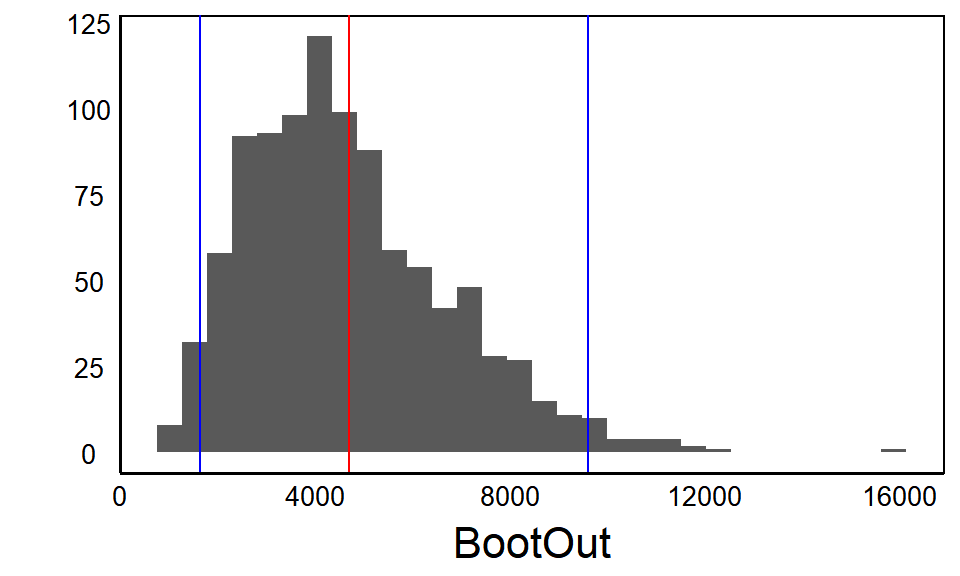

```r
# Plot
qplot(BootOut)+geom_vline(aes(xintercept=Xboot),colour="red")+geom_vline(aes(xintercept=CIlow),colour="blue")+geom_vline(aes(xintercept=CIhigh),colour="blue")
```

> Why does the 95% CI seem so much wider on this plot than the previous two?

This is a plot of estimated population means from the bootstrap iterations, whereas the previous graphs plot the raw data. Therefore the x-axis scales are quite different.

## Compare methods

Let’s look at all of them together:

```r
# Transform bootstrap values
Xboot<-round(Xboot)
CIboot<-round(CIboot)

cat("Raw mean is:",X,"\n",
    "Raw 95% CI is:",CI[1],"to",CI[2],"\n",
    "Transformed mean is:",Xlog,"\n",
    "Transformed 95% CI is:",CIlog[1],"to",CIlog[2],"\n",
    "Bootstrap mean is:",Xboot,"\n",
    "Bootstrap 95% CI is:",CIboot[1],"to",CIboot[2],"\n")
```

```
## Raw mean is: 4601
##  Raw 95% CI is: 561 to 8640
##  Transformed mean is: 124
##  Transformed 95% CI is: 100 to 153
##  Bootstrap mean is: 4694
##  Bootstrap 95% CI is: 1640 to 9601
```

> Which method is most accurate and why?

## Bootstrap: Effect Size

We can also use a bootstrap simulation as a non-parametric statistic. In the dataset on *Alliaria petiolata* (garlic mustard) from the Global Garlic Mustard Field Survey there is a factor called **Region**, which tells us which continent the population is on. Let’s test if the North American populations are larger than populations in Europe.

## Parametric Models

```r
# Raw data
RawMod<-lm(Pop_Size~Region,data=GMsubDat)
(RawCoef<-summary(RawMod)$coefficients)
```

```
##                Estimate Std. Error   t value   Pr(>|t|)
## (Intercept)    453.8455   3168.477 0.1432377 0.88617623
## RegionNorthAm 7147.6219   4159.867 1.7182332 0.08654573
```

```r
# Log-transformed
LogMod<-lm(log_Size~Region,data=GMsubDat)
(LogCoef<-summary(LogMod)$coefficients)
```

```
##               Estimate Std. Error   t value     Pr(>|t|)
## (Intercept)   4.016636  0.1600753 25.092168 1.768767e-83
## RegionNorthAm 1.382294  0.2101615  6.577295 1.538992e-10
```

Recall: The ‘RegionNorthAm’ parameter is the estimated difference in the mean of North American population size relative to Europe. The 2nd model is on a log-scale so it needs to be back-transformed.

```r
# Calculate effect size and parametric 95%CI, and round
RawES<-round(RawCoef[2])
RawCI<-round(c(RawCoef[2]-1.96*RawCoef[4],RawCoef[2]+1.96*RawCoef[4]))

# Calculate for log-transformed
LogES<-exp(LogCoef[2])
LogES<-round(LogES)
LogCI<-exp(c(LogCoef[2]-1.96*LogCoef[4],LogCoef[2]+1.96*LogCoef[4]))
LogCI<-round(LogCI)

cat("The effect size based on raw data is:",RawES,"\n",
    "with parametric 95% CI of",RawCI[1],"to",RawCI[2],"\n",
    "The effect size based on transformed data is:","\n",
    LogES,"with parametric 95% CI of",LogCI[1],"to",LogCI[2],"\n")
```

```
## The effect size based on raw data is: 7148
##  with parametric 95% CI of -1006 to 15301
##  The effect size based on transformed data is:
##  4 with parametric 95% CI of 3 to 6
```

> What does the range of CI values tell you about the hypothesis that introduced populations (North America) are larger than populations in the native range (Europe)?

## A Bootstrap model

We sample, with replacement, just as we did with the above bootstrap model. However, this time we sample separately for each region and calculate the difference in the mean each time

1. Resample the data **from each region**, with replacement
2. Calculate the **difference between means**
3. Repeat N times
4. Calculate the mean of the N replicated samples. This is the **bootstrap effect size**.
5. The 0.025*Nth smallest mean is the lower 95% CI
6. The 0.975*Nth smallest mean is the upper 95% CI

```r
Iters<-999 # Number of iterations == the number ot times the mean is resampled
BootESOut<-rep(NA,Iters) # Make an empty vector with # cells = number of iterations
# Make separate EU/NA groups for resampling
EUpops<-GMsubDat$Pop_Size[grep("Europe",GMsubDat$Region)]
NApops<-GMsubDat$Pop_Size[grep("NorthAm",GMsubDat$Region)]
for (i in 1:Iters){
  # Resample the data, calculate the mean, and save it in a vector; repeat
  BootESOut[i]<-
    mean(sample(NApops,length(NApops),replace=T)) -
    mean(sample(EUpops,length(EUpops),replace=T))
}
head(BootESOut)
```

```
## [1]  3171.518  9514.236 10213.996  8095.051  5657.564 14997.037
```

Look at the frequency histogram.

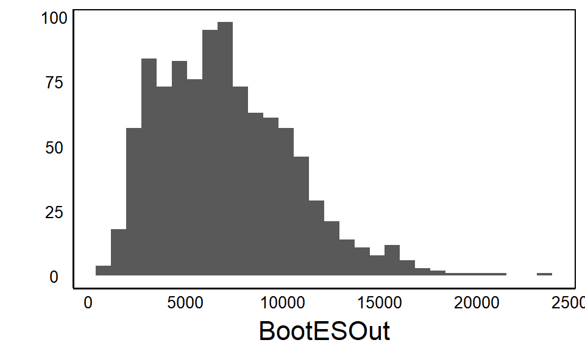

```r
qplot(BootESOut)
```

Compare the results

```r
# Calculate mean & 95% CI
XbootES<-round(mean(BootESOut))
CIlowES<-sort(BootESOut)[floor(length(BootESOut)*0.025)] # Lower 2.5% CI
CIhighES<-sort(BootESOut)[ceiling(length(BootESOut)*0.975)] # Upper 2.5% CI
CIbootES<-round(c(CIlow,CIhigh))

# Compare results
cat("The effect size based on raw data is:",RawES,"\n",
    "with parametric 95% CI of",RawCI[1],"to",RawCI[2],"\n",
    "The effect size based on transformed data is:",LogES,"\n",
    "with parametric 95% CI of",LogCI[1],"to",LogCI[2],"\n",
    "The effect size of the bootstrap model is:",XbootES,"\n",
    "with 95% CI of",CIbootES[1],"to",RawCI[2],"\n")
```

```
## The effect size based on raw data is: 7148
##  with parametric 95% CI of -1006 to 15301
##  The effect size based on transformed data is: 4
##  with parametric 95% CI of 3 to 6
##  The effect size of the bootstrap model is: 7114
##  with 95% CI of 1640 to 15301
```

> What do the x- and y-axis represent, and why does the distribution have this shape?

## Bootstrap Null Models

In the above model, we know our effect size is significant – i.e. North American populations are significantly bigger than native populations. But, there are two problems:

1. We don’t know the exact P-value.
2. The above model wouldn’t work for **constrained data**. For example, what if we wanted to test the significance of eigenvalues from a principal components model? Eigenvalues are **constrained** to be greater than zero. Since we calculate 95% CI from resampled data, rather than a parametric model, we can’t just check if our 95% CI overlap zero.

Here’s where a null model comes in handy. We first define and simulate a null model, then compare our observed value(s) to the null model.

Defining the null model is a little more tricky – you have to think in terms of the null hypothesis. In our example, the null hypothesis is that there is no difference in the size of European and North American populations. To generate a null distribution:

```r
Iters<-999 # Number of iterations == the number ot times the mean is resampled
PermOut<-rep(NA,Iters) # Make an empty vector with # cells = number of iterations
SimDat<-GMsubDat # Make a new dataset for resampling
for (i in 1:Iters){
  # 1. Reshuffle Region labels (sample, without replacement)
  SimDat$Region<-sample(SimDat$Region,replace=F)
  # 2. Calculate effect size and save in output vector
  PermOut[i]<-
    mean(SimDat$Pop_Size[grep("NorthAm",SimDat$Region)]) -
    mean(SimDat$Pop_Size[grep("Europe",SimDat$Region)])
}
head(PermOut)
```

```
## [1]   693.9003 -2882.2031   405.0679 -5380.2497 -3163.3867 -2056.8264
```

## Plot Null

```r
# Calculate mean difference of raw data
(RawX<-aggregate(GMsubDat$Pop_Size,list(GMsubDat$Region),mean))
```

```
##   Group.1         x
## 1  Europe  453.8455
## 2 NorthAm 7601.4673
```

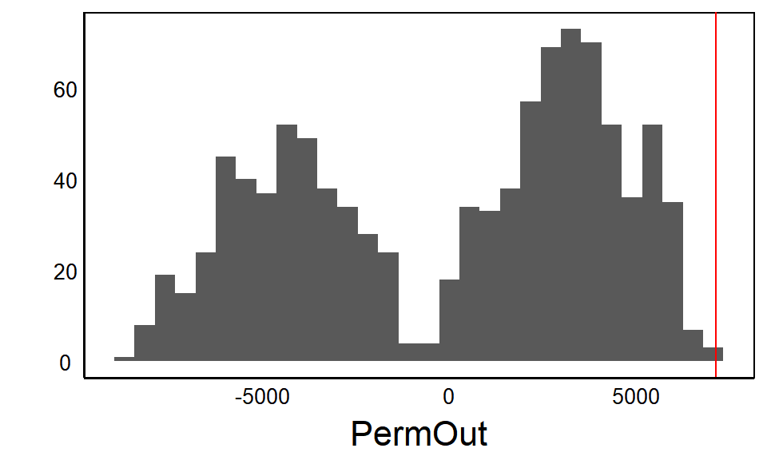

```r
RawDiff<-RawX$x[2]-RawX$x[1]
qplot(PermOut)+geom_vline(aes(xintercept=RawDiff),colour="red")
```

## Calculate p-value

```r
p<-sum(PermOut>RawDiff)/length(PermOut)
paste("The estimated p-value is:",p)
```

```
## [1] "The estimated p-value is: 0"
```

If we did not have an *a priori* prediction about the direction of the effect, then it is a 2-tailed test. This is easy to do. We just divide alpha by two, or multiply the p-value by 2.

In our case, our null hypothesis was no difference between European vs. North American populations (rather than testing whether North American populations are bigger).

So p < 0.01 for 1001 iterations or p < 0.001 if there is no overlap in 2001 iterations.

## Bootstrap Caveats

It’s important to think carefully about your bootstrap and null models and the implicit assumptions you make when you run them. For example, we assume that each observation has the same probability of being chosen in each iteration. This wouldn’t be true if there was some sort of inherent correlation among data points. For example, the data we are working with were sampled non-randomly.

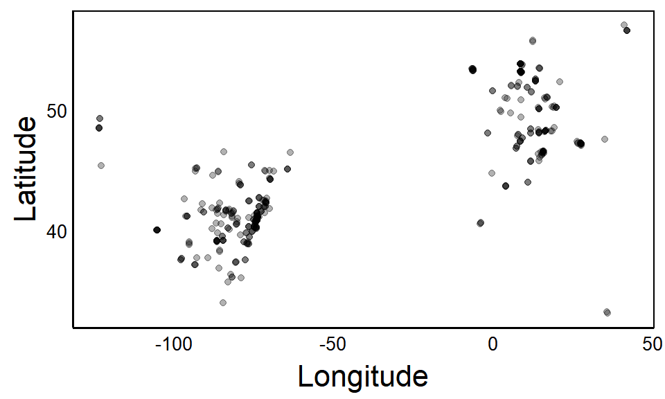

```r
qplot(Longitude,Latitude,data=GMdat,alpha=I(0.3))
```

We may also have two or more factors in a model that are correlated. For example, multiple traits measured on the same individuals or the same traits measured on the same individuals but at different time points. In this kind of ‘repeated measures’ experiments, should run the bootstrap and null model tests at the level of individual, not observation. That is, reshuffle ID tags for a null model, leaving the rest of the row/column data untouched.

## Make it faster

Once you understand the basic coding for bootraps and permutation tests, you can look into available packages to reduce the amount of code you need to write and have them run faster.

The `lmPerm` package is the permutation equivalent of `lm()`

The `boot` package has tools for writing bootstrap models

The `foreach` and `doParallel` packages allow you to use multithreading in your functions and for-loops.

# Cross-validation

In contrast to the bootstrap, which resamples data, cross-validation provides an alternative approach that is not as computationally demanding. Rather than resampling randomly, in each iteration, k rows of data (typically k=5 or k=10) are removed from the dataset in each iteration.

Cross-validation is useful for identifying the best-fit statistical models while avoiding over-fitting. The `cv.glm` function from the `boot` package does this quickly:

```r
library(boot)
mod1<-glm(Pop_Size~Latitude*Region,data=GMsubDat)
summary(mod1)
```

```
##
## Call:
## glm(formula = Pop_Size ~ Latitude * Region, data = GMsubDat)
##
## Deviance Residuals:
##    Min      1Q  Median      3Q     Max
## -23296   -7497    -513    -333  729870
##
## Coefficients:
##                        Estimate Std. Error t value Pr(>|t|)
## (Intercept)             1503.96   41569.75   0.036    0.971
## Latitude                 -21.23     837.85  -0.025    0.980
## RegionNorthAm          96260.35   61744.46   1.559    0.120
## Latitude:RegionNorthAm -2169.79    1388.73  -1.562    0.119
##
## (Dispersion parameter for gaussian family taken to be 1648405060)
##
##     Null deviance: 6.5257e+11  on 392  degrees of freedom
## Residual deviance: 6.4123e+11  on 389  degrees of freedom
## AIC: 9461.9
##
## Number of Fisher Scoring iterations: 2
```

```r
cv.err<-cv.glm(GMsubDat,mod1)
cv.err$K
```

```
## [1] 393
```

```r
cv.err$delta
```

```
## [1] 1671500822 1671449762
```

Our `cv.err$delta` parameters are the Cross-Validation estimates of the model Mean Squared Error (MSE), which is just an average of the individual model MSEs:

$CV = \frac{\sum_{i=1}^k MSE_i}{k}$

Where MSE is just the average squared deviation of each point $y_i$ from the model prediction $\hat f(x_i)$ :

$MSE = \frac{\sum_{i=1}^n [(y_i - f(x_i)]^2}{n}$

We can try higher-order polynomials with the continuous term (Latitude)

```r
library(boot)
Plvl<-8
cv.err<-rep(NA,Plvl)
for (i in 1:Plvl){
  mod1<-glm(Pop_Size~poly(Latitude,i),data=GMsubDat)
  cv.err[i]<-cv.glm(GMsubDat,mod1)$delta[1]
  mod1<-NA
}
cv.err
```

```
## [1] 1664026632 1672136263 1676067184 1676550858 1688583242 1694108380
## [7] 1695177036 1702342201
```

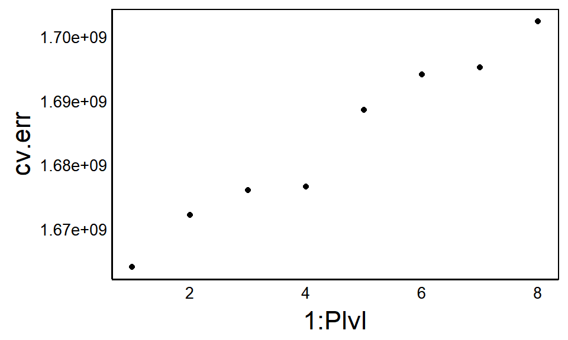

```r
qplot(x=1:Plvl,cv.err)
```

And include interactions of each polynomial with Region:

```r
library(boot)
Plvl<-8
cv.err<-rep(NA,Plvl)
for (i in 1:Plvl){
  mod1<-glm(Pop_Size~poly(Latitude,i)*Region,data=GMsubDat)
  cv.err[i]<-cv.glm(GMsubDat,mod1)$delta[1]
  mod1<-NA
}
cv.err
```

```
## [1]  1671500822  1684443310  1687263035  1702668949  1940242052  2695336604
## [7]  2168512452 10946879640
```

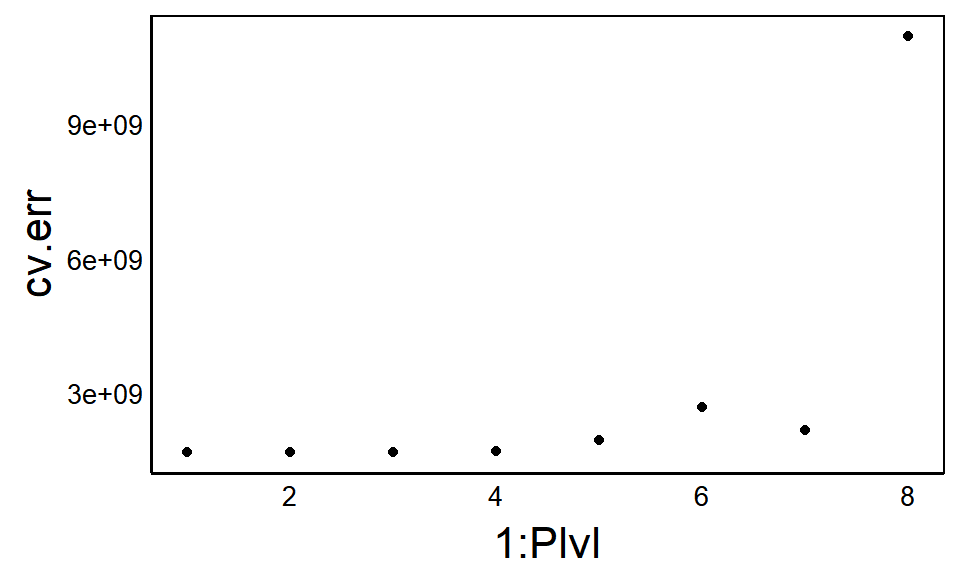

```r
qplot(x=1:Plvl,cv.err)
```

# Assignment

Analyze a biological dataset to address any biological question (ideally one of your own or from your lab). Analyze the data using `glm()` with at least one continuous (i.e. numeric) predictor variable. Use a cross-validation approach to determine the ‘best’ mode. Write a short report using R markdown that explains your approach (methods), hypothesis, and inference.